# World Progress and Development Indicators

## Nicholas Hopewell - 0496633

This report is intended to present and discuss simple and effective visualizations in an insightful way. Furthermore, every plot is print-friendly and so interactive visualization techniques were not the goal of the current report. These plots could easily be made interactive - making plots entirely interactive (for brushing, selecting points, etc) is a single line of code with ggplot2 and plotly. Most of the design decisions for the visualizations within this report were inspired by the ideas of Edward Tufte and the teachings of Steven Few. Finally, it is my hope that the data I chose is interesting and understandable to wide audiences. It was an intentional decision to avoid visualizing a very specific data set. Instead, I wanted to do more broad visualizations of many related data sets.

What this report should convey:

1. Clean and understandable visualizations of world development indicators.
2. Explainations of various relationships in the data.

What this report does not include:

1. Interactive visualizations.
2. Complex, rarely-used, and hard to understand visualizations.

This report will be organized in sections with headings that capture a key insight of the associated vizualization(s).

These graphs may be designed with simplicity in mind, but the actual data wrangling involved was not simple whatsoever. This project was most interesting to me because it forced me to have ‘data intuition.’ Before producing anything, I needed to know what the data could be molded into, how it could be reshaped, and ultimately, what visualizations were possible with the data I wanted to use. Not a single data file used for this project was in a format which made data visualization easy. Each piece of data had a few interesting stories to tell with some being more interesting than others. I won’t go into much detail on the preprocessing specifically as I have attached a total of 9 R script files which include the work. Most of the tidyverse tools were used before visualizing the data. The brunt of the preprocessing work involved lots of reshaping, aggregation and summarizing. There was also quite a lot of text work involved with country and region names as well as a lot of function-writing. All data eventually arrived at a tidy data frame to plot with ggplot2. Simply finding the data I wanted was very difficult. I spend many, many days searching through government records to find data which was complete enough to visualize and interesting enough to get a least a little bit excited about.

# Education funding has increased everywhere except North America

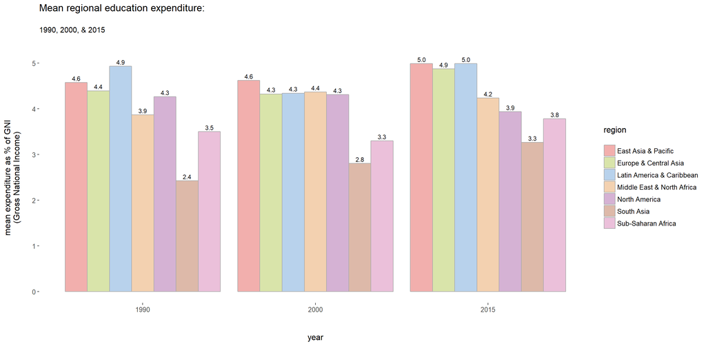

This plot shows mean education expenditure in different regions of the world for the years 1990, 2000, and 2015. Education expenditure is calculated across regions as the percent of gross national income (GNI) spent funding education. The x-axis including uneven spacing between years was intentional; the onlooker ought to have the ability to compare the most recently available data to a couple recognizable years going relatively far back in recent time. Some valuable information is gained from this plot quite easy with almost no effort or interpretation required from the viewer. This is perhaps one of the greatest strengths of the simple bar plot and surely a contributing factor towards it wide-spread use within analytics. That being said, there are a lot of subtle design choices I have made with this particular bar plot (and a couple others included in this report) which enhance its readability and feel but could easily go unappreciated by an individual who has not studied data visualization formally. I will elaborate on these choices after explaining some take-aways from this plot.

It’s clear that overall, average educational expenditure across regions has increased from 1990 to 2000, and again from 2000 to 2015 for most regions. Some regions did not improve from 1990 to 2000, but almost every region in the world improved from 1900 to 2015. Some regions increased educational expenditure more than others, with South Asia making the largest progress over 25 years and Latin America/Caribbean making only small progress. One interesting outcome is that North America is the only region who has not increased their educational expenditure but rather spent a lower percentage of it’s GNI on education in 2015 than it did in 1990 and 2000. There are many reasons why this could be the case, reasons which like are rooted in policy and new capitalist economy. It would be unwise to attempt to explain this outcome without more information. It might be interesting to split this region into Canada and America to get a better sense of what factors are influencing these numbers.

The design decisions come directly from Few and Tufte down to the very last detail. The use of white space is maximized by reducing all unnecessary non-data ink. I tend to agree that discrete y-axes can often be left out of a plot without losing any information (assuming the y values are included). In this case, leaving out the x-axis line is not only okay, but I think advantageous in that it makes it even easier to group the years together. The colour palette used here (and throughout most of these displays) come directly from the recommendations of Few. The actual colours are quite faded and not so deep as per Few’s recommendations for bar plots (since bars already have a lot of visual weight to them). Also notice that the number of regions is exactly seven so not to be confusing and hard to visually understand. The recommended but of unique hues according to Few is at eight at most. To make this plot even more print friendly I included a subtle dark grey outline around each bar to make the display pop off the page to the viewer. I also included the actual values above each bar, again for print friendliness. All together, this plot is very clean and elegant.

One very subtle, rarely appreciated, but a very important contributor to the message being portrayed through this plot is the actual height I have chosen for the bars. One might look at this plot and not notice that I have made the y-axis slightly longer than the normal y - x ratio of a bar plot (or any plot which is wider than taller). This was an intentional decision and was not one meant to mislead the viewer nor exaggerate a claim. Personally, after putting a lot of thought into the height of the bars, I concluded that augmenting the length of y-axis really would help get across the current message more clearly. The plot above shows average percentages of a whole (GNI). In this case, the whole is quite massive - it’s an entire regions gross national income. If one takes the time to consider expenditure of GNI, the difference between spending 4% and 5% of an entire regions gross national income on education is really a large and very meaningful difference (especially if you were to ask any principal or teacher). Being able to slightly emphasize how large of a difference even a one percent makes in this case allows that difference to feel more real to the viewer. It also helps the viewer more easily compare between regions and within regions across years. All together, I believe it was an effective design choice.

# Female secondary enrollment higher than male secondary enrollment in most areas of South Asia

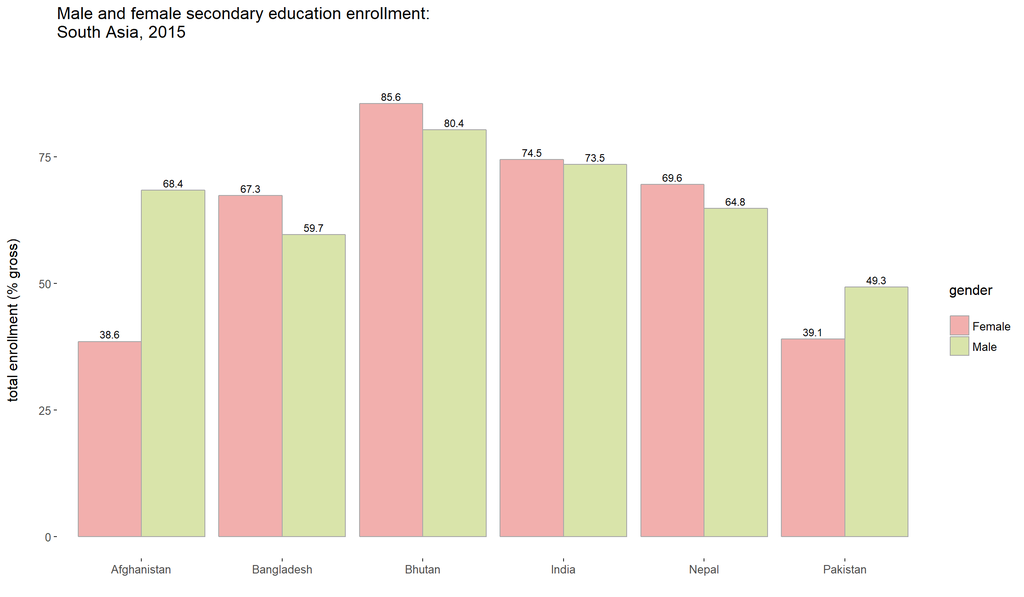

This plot follows much of the same design decisions I used above with one key difference. The visual weight of the features of this plot is slightly different than the one above. I didn’t adjust the vertical height of this plot but instead kept the width more predominant, again, to better show the message I wanted the reader to see. I chose South Asia because it had the largest improvement in mean educational expenditure in the first visualization. Here, we are looking at education enrollment in different countries of South Asia in 2015. The important part, though, is to understand how education enrollment is different between genders in these countries. Because the genders are grouped side-by-side, the width of each bar makes the separation more obvious and important to the viewer. The colours and white space are again based off the recommendations of Tufte and Few. Hue works particularly well here for associating the quantitative values (total enrollment) with the categorical values (gender).

It should be noted that here, raw percentages are being visualized rather than means (as in the first plot). Here we can see that in most regions of South Asia, more females were enrolled in secondary school than males in 2015. The country with the largest difference between male and female enrollment (in favor of females) is Bangladesh while secondary enrollment in Indian is roughly even between genders. Interestingly, in Pakistan and especially Afghanistan, males are much more likely to have enrolled in secondary schools than females in 2015.

# Global number of deaths by natural disaster falling, extreme temperature deaths more common

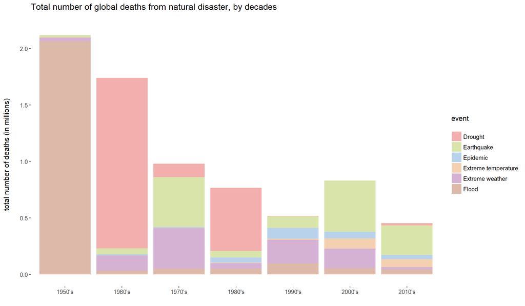

This stacked bar chart is a classic example of a way to visualize parts of a whole. It is important to know that this plot does not display an exhaustive list of natural disasters measured. A few underrepresented disaster types where stripped from the visualization to make the categories easier to see and map to their associated hues. The maximum number of unique values of a categorical variable which should be represented by hue (eight) felt cluttered when applied to this plot. Because of this, I chose to visualize six of the categories. All the most notable disaster types (in terms of their presence in the data set) were retained. To briefly touch on the hue choice, I did again go with the direct recommendations from Steven Few for bars (or any large graphical object) by making the colours more washed-out. However, some of the categories are represented visually with quite small areas in the plot (slivers on the bars). One might argue that in these cases, we ought to make the ink more vibrant to really capture those small, but perhaps important, category values. I tried that approach and it did not look as clean and ended up making the smaller category values more ambiguous. This, I found, was because the choice to have many vibrant colours so close together in a relatively small area made the categories compete for your visual attention (they seemed harder to recognize). Here, I believe Few’s guidelines still apply perfectly well and the vibrancy of the ink is just right. Also, as the visual weight of each bar is even more pronounced in this plot compared to the previous bar plots, outlining the bars did not add any visual aid so I chose to omit that ink. Furthermore, because this type of plot is more about making relative comparisons between stacked categories, I did not choose to include any actual values as I did in the previous examples. Briefly, I considered adding overall occurrence counts (in millions) but I do not think it is necessary nor interesting here. Sticking to my running theme of clean, classic, and print-friendly, this plot achieves those goals.

# Cost of natural disasters increasing with devastating potentials

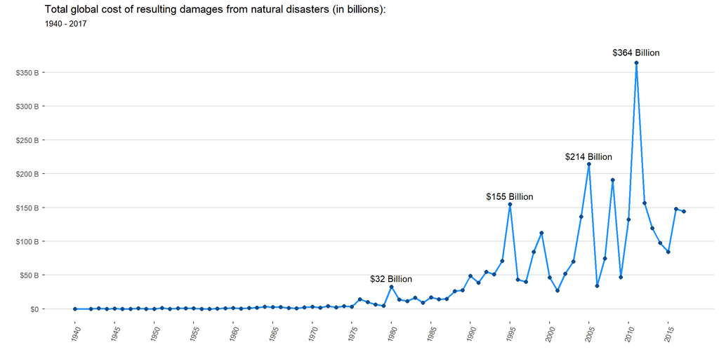

The obvious message this plot portrays is that global costs resulting from natural disasters is increasing over time but that this increase is inconsistent (spikey). This makes sense due to the natural and severity of natural disasters, where they strike and what infrastructure and live they demolish. Personally, I think the more interesting story is the shear potential for devastation these disasters may carry. That is the story I really wanted to tell. Showing others the potential impact of disasters, rather than that they are simply increasing over time, might act as a better call-to-arms towards the exploration of better climate research and disaster control procedures. At the very least it brings to life an important message.